# SI 618 - Homework #1: Data Manipulation

## Background

This homework assignment focuses on the analysis of historical data from the Olympic games. The description of the data includes the following:

> This is a historical dataset on the modern Olympic Games, including all the Games from Athens 1896 to Rio 2016. I scraped this data from www.sports-reference.com in May 2018.

Your main task in this assignment is to explore the data *using the data manipulation methods we covered in class* as well as those in the assigned readings. You may need to consult pandas documentation, Stack Overflow, or other online resources.

**You should also feel free to ask questions on the class Slack channel!**

A total of 100 points is available in this homework assignment, consisting of:

- 80 points for completing the specific homework questions. More comprehensive answers will tend to gain more points.
- 10 points for the overall quality of spelling, grammar, punctuation, and style of written responses. (see https://drive.google.com/file/d/1L0P7xJwjUGBvyb49mL3dw1Bt7hzRTiTl/view for a detailed specifications).
- 10 points for creating code that conforms to [PEP 8](https://www.python.org/dev/peps/pep-0008/) guidelines. You should review those guidelines before proceding with the assignment.

## 0. Download the data from:

- https://www.kaggle.com/heesoo37/120-years-of-olympic-history-athletes-and-results

NOTE: You will only need the file named "athlete_events.csv"

```python
MY_UNIQNAME = 'drewpap'
```

## 1. Answer the questions below.

For each question, you should

1. Write code using Python and pandas that can help you answer the following questions, and
2. Explain your answers in plain English. You should use complete sentences that would be understood by an educated professional who is not necessarily a data scientist (like a product manager).

### 5 pt: Describe the dataset.

- How many number rows and columns do you see in the data frame?
- Are there any other interesting descriptive details?

```python
import pandas as pd
import numpy as np
athlete_data = pd.read_csv('data/athlete_events.csv')
athlete_data
```

|  | ID | Name | Sex | Age | Height | Weight | Team | NOC | Games | Year | Season | City | Sport | Event | Medal |
| --- | --- | --- | --- | --- | --- | --- | --- | --- | --- | --- | --- | --- | --- | --- | --- |
| 0 | 1 | A Dijiang | M | 24.0 | 180.0 | 80.0 | China | CHN | 1992 Summer | 1992 | Summer | Barcelona | Basketball | Basketball Men's Basketball | NaN |
| 1 | 2 | A Lamusi | M | 23.0 | 170.0 | 60.0 | China | CHN | 2012 Summer | 2012 | Summer | London | Judo | Judo Men's Extra-Lightweight | NaN |
| 2 | 3 | Gunnar Nielsen Aaby | M | 24.0 | NaN | NaN | Denmark | DEN | 1920 Summer | 1920 | Summer | Antwerpen | Football | Football Men's Football | NaN |
| 3 | 4 | Edgar Lindenau Aabye | M | 34.0 | NaN | NaN | Denmark/Sweden | DEN | 1900 Summer | 1900 | Summer | Paris | Tug-Of-War | Tug-Of-War Men's Tug-Of-War | Gold |
| 4 | 5 | Christine Jacoba Aaftink | F | 21.0 | 185.0 | 82.0 | Netherlands | NED | 1988 Winter | 1988 | Winter | Calgary | Speed Skating | Speed Skating Women's 500 metres | NaN |
| ... | ... | ... | ... | ... | ... | ... | ... | ... | ... | ... | ... | ... | ... | ... | ... |
| 271111 | 135569 | Andrzej ya | M | 29.0 | 179.0 | 89.0 | Poland-1 | POL | 1976 Winter | 1976 | Winter | Innsbruck | Luge | Luge Mixed (Men)'s Doubles | NaN |
| 271112 | 135570 | Piotr ya | M | 27.0 | 176.0 | 59.0 | Poland | POL | 2014 Winter | 2014 | Winter | Sochi | Ski Jumping | Ski Jumping Men's Large Hill, Individual | NaN |
| 271113 | 135570 | Piotr ya | M | 27.0 | 176.0 | 59.0 | Poland | POL | 2014 Winter | 2014 | Winter | Sochi | Ski Jumping | Ski Jumping Men's Large Hill, Team | NaN |
| 271114 | 135571 | Tomasz Ireneusz ya | M | 30.0 | 185.0 | 96.0 | Poland | POL | 1998 Winter | 1998 | Winter | Nagano | Bobsleigh | Bobsleigh Men's Four | NaN |
| 271115 | 135571 | Tomasz Ireneusz ya | M | 34.0 | 185.0 | 96.0 | Poland | POL | 2002 Winter | 2002 | Winter | Salt Lake City | Bobsleigh | Bobsleigh Men's Four | NaN |

271116 rows × 15 columns

There are 271116 rows and 15 columns in the imported data frame. There are a couple of interesting things about the dataset. Several of the measurements are in metric, so in order to communicate effectively with American audiences, they ought to be converted to imperial.

### 5 pt: Without using dataframe.describe(), calculate the mean age, height, and weight for athletes in the data. Round your answer to the nearest hundredths.

```python
#Visualize data
athlete_data['Age'].plot.hist(bins = 30)
athlete_data['Height'].plot.hist(bins = 30)
athlete_data['Weight'].plot.hist(bins = 30)

#Check for outliers that may skew the mean
print(f"Max age: {athlete_data['Age'].max()}")
print(f"Max Height in cm: {athlete_data['Height'].max()}")
print(f"Max Weight in kg: {athlete_data['Weight'].max()} \n")

print(f"Min Age: {athlete_data['Age'].min()}")
print(f"Min Height in cm: {athlete_data['Height'].min()}")
print(f"Min Weight in kg: {athlete_data['Weight'].min()}\n")

print(f"Median Age: {round(athlete_data['Age'].median(),2)}")
print(f"Median Height in cm: {round(athlete_data['Height'].median(),2)}")
print(f"Median Weight in kg: {round(athlete_data['Weight'].median(),2)}\n")

# #Calculate and round means
print(f"Mean Age: {round(athlete_data['Age'].mean(),2)}")
print(f"Mean Height in cm: {round(athlete_data['Height'].mean(),2)}")
print(f"Mean Weight in kg: {round(athlete_data['Weight'].mean(),2)}")
```

```
Max age: 97.0
Max Height in cm: 226.0
Max Weight in kg: 214.0

Min Age: 10.0
Min Height in cm: 127.0
Min Weight in kg: 25.0

Median Age: 24.0
Median Height in cm: 175.0
Median Weight in kg: 70.0

Mean Age: 25.56
Mean Height in cm: 175.34
Mean Weight in kg: 70.7
```

To be on the safe side, I also checked for the minimums and maximums for each category. All of the values are plausible values for a person's height, age, and weight, so we ought not worry about single values pulling the mean. Finally, I calculated the medians for each category to compare them to the calculated mean and found that both the mean and median are very similar to one another, further confirming the belief that the mean is not skewed.

With those checks in place the calculated mean age is 25.56 years old, the mean height is 175.34 centimeters tall, and the mean weight is 70.7 kilograms.

### 5 pt: According to the data, how many unique cities have hosted the Olympic games? How many cities have hosted mutliple times? Which ones?

You will likely want to use drop_duplicates() on some subset of your athlete dataframe.

```python
#Number of unique cities that have hosted the olympic games
print(f"{len(athlete_data.City.unique())} unique cities have hosted the olympic games.\n")

#Filter to get the number of olympic games that have happened
unique_olympic_games = athlete_data.drop_duplicates(['Games']).sort_values(by ='Games')

#Get the number of times each city appears in the data frame
olympic_games_hosting_counts = unique_olympic_games["City"].value_counts()

#Return only the cities who have more than one hosted event
print("These cities have hosted more than one Olympic games:\n")
for city in olympic_games_hosting_counts[olympic_games_hosting_counts > 1].index:
    print(city)
```

```
42 unique cities have hosted the olympic games.

These cities have hosted more than one Olympic games:

Athina
London
Lake Placid
Innsbruck
Los Angeles
Sankt Moritz
Paris
```

To find the number of unique cities that have hosted the Olympic games I utilized the .unique() function to return all of the unique cities in the athlete_data dataframe. From that analysis, we see that 42 unique cities have hosted the Olympic games.

To find which cities have hosted multiple times, I created a new data frame that removes all duplicate games. I decided to use the games column for removing duplicates because I consider an event "hosted" if the vast majority of events were hosted within that city. In this sense, any olympic games where another city hosted an event for whatever reason is not included in the count. This is relevant if you consider the 1956 olympics. Stockholm hosted the equestrian event instead of Melbourne because of quarantine restrictions. However, because Melbourne hosted the majority of the events, Stockholm is not double counted. That said, I used the value_counts() function and found all cities appearing more than once. Seven cities have hosted the Olympic games more than once: Athina, London, Lake Placid, Los Angeles, Sankt Moritz, Innsbruck, and Paris.

### 10 pt: Generate histogram plots for the age, weight, and height for Norwegian female athletes who competed in the 1970s. Describe the plots and point out any interesting aspects.

```python
#Check that sex data is clean and does not include lowercase values
print(athlete_data["Sex"].unique())

#Select norwegian, gender female, in year 1970
nor_fem_athletes_1970s = athlete_data[(athlete_data["Year"] > 1969) &
                                      (athlete_data["Year"] < 1980) &
                                      (athlete_data["Sex"] == "F") &
                                      (athlete_data["NOC"] == "NOR")].drop_duplicates(["Name"])
nor_fem_athletes_1970s
```

```
['M' 'F']
```

|  | ID | Name | Sex | Age | Height | Weight | Team | NOC | Games | Year | Season | City | Sport | Event | Medal |
| --- | --- | --- | --- | --- | --- | --- | --- | --- | --- | --- | --- | --- | --- | --- | --- |
| 6755 | 3788 | Grete Andersen-Waitz | F | 18.0 | 172.0 | 53.0 | Norway | NOR | 1972 Summer | 1972 | Summer | Munich | Athletics | Athletics Women's 1,500 metres | NaN |
| 7387 | 4131 | Trine Helene Andresen (-Svendheim) | F | 16.0 | 158.0 | 54.0 | Norway | NOR | 1972 Summer | 1972 | Summer | Munich | Gymnastics | Gymnastics Women's Individual All-Around | NaN |
| 10875 | 5937 | Inger Reidun Aufles (Dving-) | F | 30.0 | 165.0 | 54.0 | Norway | NOR | 1972 Winter | 1972 | Winter | Sapporo | Cross Country Skiing | Cross Country Skiing Women's 5 kilometres | NaN |
| 10973 | 5994 | Berit Kristine Aunli-Kvello | F | 19.0 | 170.0 | 56.0 | Norway | NOR | 1976 Winter | 1976 | Winter | Innsbruck | Cross Country Skiing | Cross Country Skiing Women's 5 kilometres | NaN |
| 21606 | 11407 | Kirsti Biermann | F | 21.0 | 172.0 | 65.0 | Norway | NOR | 1972 Winter | 1972 | Winter | Sapporo | Speed Skating | Speed Skating Women's 500 metres | NaN |
| 28612 | 14831 | Ingun Brechan (-Pettersen-) | F | 22.0 | 177.0 | 72.0 | Norway | NOR | 1976 Summer | 1976 | Summer | Montreal | Rowing | Rowing Women's Double Sculls | NaN |
| 30753 | 15846 | Anne Brusletto (-Heje) | F | 21.0 | 168.0 | 55.0 | Norway | NOR | 1972 Winter | 1972 | Winter | Sapporo | Alpine Skiing | Alpine Skiing Women's Giant Slalom | NaN |
| 41280 | 21292 | Karianne Christiansen | F | 22.0 | 175.0 | 61.0 | Norway | NOR | 1972 Winter | 1972 | Winter | Sapporo | Alpine Skiing | Alpine Skiing Women's Downhill | NaN |
| 48169 | 24834 | Aslaug Magna Dahl | F | 22.0 | 170.0 | 52.0 | Norway | NOR | 1972 Winter | 1972 | Winter | Sapporo | Cross Country Skiing | Cross Country Skiing Women's 5 kilometres | NaN |
| 62149 | 31827 | Sidsel Ekholdt (-Hilleren) | F | 16.0 | 162.0 | 50.0 | Norway | NOR | 1972 Summer | 1972 | Summer | Munich | Gymnastics | Gymnastics Women's Individual All-Around | NaN |
| 70046 | 35680 | Torill Fjeldstad | F | 17.0 | 175.0 | 65.0 | Norway | NOR | 1976 Winter | 1976 | Winter | Innsbruck | Alpine Skiing | Alpine Skiing Women's Downhill | NaN |
| 71901 | 36588 | Toril Marit Frland | F | 17.0 | 170.0 | 58.0 | Norway | NOR | 1972 Winter | 1972 | Winter | Sapporo | Alpine Skiing | Alpine Skiing Women's Downhill | NaN |
| 90152 | 45681 | Bente Hansen (-Foss) | F | 19.0 | 164.0 | 50.0 | Norway | NOR | 1972 Summer | 1972 | Summer | Munich | Gymnastics | Gymnastics Women's Individual All-Around | NaN |
| 97754 | 49475 | Unni Elisabeth Holmen (-Berge-) | F | 19.0 | 165.0 | 56.0 | Norway | NOR | 1972 Summer | 1972 | Summer | Munich | Gymnastics | Gymnastics Women's Individual All-Around | NaN |
| 107747 | 54462 | Lene Jenssen (-Holmertz) | F | 19.0 | 178.0 | 62.0 | Norway | NOR | 1976 Summer | 1976 | Summer | Montreal | Swimming | Swimming Women's 100 metres Freestyle | NaN |
| 108917 | 55073 | Berit Johannessen | F | 24.0 | 168.0 | 55.0 | Norway | NOR | 1976 Winter | 1976 | Winter | Innsbruck | Cross Country Skiing | Cross Country Skiing Women's 5 kilometres | NaN |
| 109037 | 55132 | Solfrid Johansen | F | 20.0 | 177.0 | 74.0 | Norway | NOR | 1976 Summer | 1976 | Summer | Montreal | Rowing | Rowing Women's Double Sculls | NaN |
| 124561 | 62905 | Lisbeth Korsmo-Berg | F | 24.0 | 160.0 | 56.0 | Norway | NOR | 1972 Winter | 1972 | Winter | Sapporo | Speed Skating | Speed Skating Women's 500 metres | NaN |
| 127371 | 64214 | Trine Krogh (-Lefvre-) | F | 17.0 | 163.0 | 52.0 | Norway | NOR | 1972 Summer | 1972 | Summer | Munich | Swimming | Swimming Women's 200 metres Individual Medley | NaN |
| 128972 | 64931 | Grete Kummen (Haugen-) | F | 23.0 | 169.0 | 58.0 | Norway | NOR | 1976 Winter | 1976 | Winter | Innsbruck | Cross Country Skiing | Cross Country Skiing Women's 5 kilometres | NaN |
| 129996 | 65439 | Jill Kvamme-Schau | F | 24.0 | 162.0 | 50.0 | Norway | NOR | 1972 Summer | 1972 | Summer | Munich | Gymnastics | Gymnastics Women's Individual All-Around | NaN |
| 152238 | 76421 | Grethe Mathiesen (-Thor) | F | 16.0 | 171.0 | 58.0 | Norway | NOR | 1972 Summer | 1972 | Summer | Munich | Swimming | Swimming Women's 100 metres Freestyle | NaN |
| 160855 | 80722 | Katharina Louise Mo-Berge | F | 27.0 | 171.0 | 58.0 | Norway | NOR | 1972 Winter | 1972 | Winter | Sapporo | Cross Country Skiing | Cross Country Skiing Women's 5 kilometres | NaN |
| 164803 | 82761 | Berit Mrdre-Lammedal | F | 31.0 | 168.0 | 57.0 | Norway | NOR | 1972 Winter | 1972 | Winter | Sapporo | Cross Country Skiing | Cross Country Skiing Women's 5 kilometres | NaN |
| 167046 | 83928 | Marit Myrml | F | 22.0 | 168.0 | 58.0 | Norway | NOR | 1976 Winter | 1976 | Winter | Innsbruck | Cross Country Skiing | Cross Country Skiing Women's 5 kilometres | NaN |
| 180251 | 90588 | Tone Astrid Pahle (-Devor) | F | 21.0 | 178.0 | 67.0 | Norway | NOR | 1976 Summer | 1976 | Summer | Montreal | Rowing | Rowing Women's Single Sculls | NaN |
| 209669 | 105281 | Gro Margit Sandberg | F | 16.0 | 165.0 | 50.0 | Norway | NOR | 1972 Summer | 1972 | Summer | Munich | Gymnastics | Gymnastics Women's Individual All-Around | NaN |
| 226005 | 113569 | Gyri Tove Srensen | F | 20.0 | 168.0 | 55.0 | Norway | NOR | 1972 Winter | 1972 | Winter | Sapporo | Alpine Skiing | Alpine Skiing Women's Downhill | NaN |
| 226081 | 113615 | Wenche Srum (-Lnnquist) | F | 21.0 | 170.0 | 53.0 | Norway | NOR | 1972 Summer | 1972 | Summer | Munich | Athletics | Athletics Women's 1,500 metres | NaN |
| 228008 | 114532 | Brit Stav (Rolseth-, -Hoen) | F | 28.0 | 164.0 | 59.0 | Norway | NOR | 1972 Summer | 1972 | Summer | Munich | Archery | Archery Women's Individual | NaN |
| 232312 | 116542 | Sigrid Milfrid Sundby-Dybedahl | F | 29.0 | 172.0 | 74.0 | Norway | NOR | 1972 Winter | 1972 | Winter | Sapporo | Speed Skating | Speed Skating Women's 500 metres | NaN |
| 245392 | 122891 | Astrid Tveit | F | 19.0 | 178.0 | 66.0 | Norway | NOR | 1976 Summer | 1976 | Summer | Montreal | Athletics | Athletics Women's High Jump | NaN |

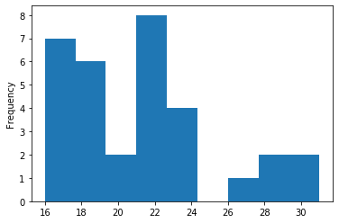

```python
#Create histogram for age
nor_fem_athletes_1970s['Age'].plot.hist(bins = 9)
```

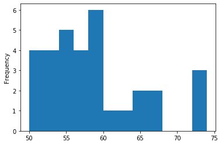

```python
#Create histogram for weight
nor_fem_athletes_1970s['Weight'].plot.hist(bins = 12)
```

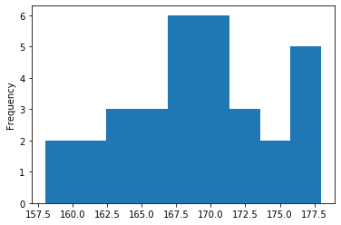

```python
#Create histogram for height
nor_fem_athletes_1970s['Height'].plot.hist(bins = 9)
```

Before creating this dataframe, I checked to see whether the data in the "Sex" column was clean by looking for unique values. After confirming the only value for females is F, I used a conditional statement on the athlete_data dataframe to get a smaller data frame that captures all Norwegian female athletes from the 1970s. The conditions specifies all events between 1970 and 1979 where the sex is "F" and the country code is NOR for Norway. Additionally, I decided to drop duplicates before calculating histograms. This assumes a consistency in height and weight across years for athletes that have competed in multiple years. This assumption is more flawed if you consider age as it is guaranteed an athlete's age will be different if they compete in multiple years. However, there are few athletes where this condition applies, so the histograms will not be influenced greatly by removing duplicates.

In each of the plots, the sample size is relatively small with no plots having a frequency of greater than 10 for any value (given the chosen bin size).

In the weight plot there is also a right skew, with the majority of athletes sitting between 50 and 60kg. One thing this plot does not show that would be interesting is the types of events the athletes competed in. The athletes that did participate in the 1970s likely were in a weight class that was competitive for their respective events, which is why we may see a cluster between 50 and 60kg.

The histogram for height is the most normally distributed of the three, however there is a surprising uptick of athletes on the taller side (between 175 and 177.5cm). There are likely correlations between the weight plot and the height plot in that taller athletes are generally also heavier.

### 10 pt: Which athlete competed in the most number of events? In which events did the athelete participate, and for what range of years? Which country did the athlete represent?

```python
#Get athlete with highest frequency in data frame
print(f"Athlete with most event partcipation: \n\n {athlete_data['Name'].value_counts().index[0]}\n")

#Get a smaller dataframe with all of the data points about that particular athlete
robert_tait_events = athlete_data[athlete_data["Name"] == "Robert Tait McKenzie"]
print(f"List of events Robert Tait McKenzie competed in:\n\n {robert_tait_events['Event'].unique()}\n")

#Get the unique years for the athlete
print(f"Unique years in which Robert Tait McKenzie competed:\n\n {robert_tait_events['Year'].unique()}\n")

#Get country for athlete
print(f"Country of athlete:\n\n {robert_tait_events['Team'].unique()[0]}")
```

```
Athlete with most event partcipation:

 Robert Tait McKenzie

List of events Robert Tait McKenzie competed in:

 ['Art Competitions Mixed Sculpturing'
 'Art Competitions Mixed Sculpturing, Statues'
 'Art Competitions Mixed Sculpturing, Medals And Reliefs'
 'Art Competitions Mixed Sculpturing, Unknown Event'
 'Art Competitions Mixed Sculpturing, Medals']

Unique years in which Robert Tait McKenzie competed:

 [1912 1928 1932 1936 1948]

Country of athlete:

 Canada
```

To find the athlete who competed in the most number of events, I found the name that appeared most frequently in the data set using the value_counts() function. The athlete who competed in the most number of events was Robert Tait McKenzie.

Robert McKenzie competed in sculpturing primarily. Looking at the unique events he appeared in, there is a varied set including statues, medals and reliefs, and medals.

Additionally, McKenzie represented Canada and competed in 5 different Summer Olympic games: 1912, 1928, 1932, 1936, and 1948.

### 10 pt: How many gold, silver, and bronze medals did Sawao Kato, one of the most successful Olympic athletes of all time, win during his Olympic career? What is the breakdown of events and medal types won for each?

```python
#Select Sawao Kato from data frame
sawao_kato_events = athlete_data[athlete_data["Name"] == "Sawao Kato"]
sawao_kato_events

#Filter out any events in which no medals were won
sawao_medal_events = sawao_kato_events[pd.notnull(sawao_kato_events["Medal"])]

#Get a count of gold, silver, and bronze medals
sawao_medal_breakdown = sawao_medal_events[["Event","Medal"]].sort_values(by = ["Medal"])
print(f"Events in which Sawao won a medal:\n\n{sawao_medal_breakdown['Event'].value_counts()}\n")
print(f"Sawao medal counts:\n\n{sawao_medal_breakdown['Medal'].value_counts()}")

#Stackoverflow aggregation reference:
#https://stackoverflow.com/questions/37932391/pandas-dataframe-combine-duplicate-columns-into-one-separate-data-by-comma

sawao_medal_breakdown.groupby(["Event"]).agg(",".join).sort_values(by = ["Medal"])
```

```
Events in which Sawao won a medal:

Gymnastics Men's Individual All-Around    3
Gymnastics Men's Team All-Around          3
Gymnastics Men's Parallel Bars            2
Gymnastics Men's Horizontal Bar           1
Gymnastics Men's Pommelled Horse          1
Gymnastics Men's Rings                    1
Gymnastics Men's Floor Exercise           1
Name: Event, dtype: int64

Sawao medal counts:

Gold      8
Silver    3
Bronze    1
Name: Medal, dtype: int64
```

| Event | Medal |
| --- | --- |
| Gymnastics Men's Rings | Bronze |
| Gymnastics Men's Floor Exercise | Gold |
| Gymnastics Men's Parallel Bars | Gold,Gold |
| Gymnastics Men's Team All-Around | Gold,Gold,Gold |
| Gymnastics Men's Individual All-Around | Gold,Gold,Silver |
| Gymnastics Men's Horizontal Bar | Silver |
| Gymnastics Men's Pommelled Horse | Silver |

To find Sawao Kato's medal count, I created a new data frame removing any events in which there was no medal. From the new data frame I did a value count on the medal column to see the breakdown. Sawao won 8 gold medals, 3 silver medals, and 1 bronze medal. To view the breakdown of the events and medal types per event, I shrunk the data frame down to only include the events and associated medals and sorted by medal. From there, I grouped the data frame and aggregated any events in which there were multiple medals. Looking at the breakdown, Sawao had the most success in the Gymnastics Men's Team All-Around in which he won three gold medals.

### 10 pt: Which sport has the lowest median athlete age?

To determine this, you might want to plot the median age for each sport. You may want to sort the axes appropriately for your analysis.

```python
#Create new data frame with only ages and sports
athlete_age_and_sport = pd.DataFrame({"Age":athlete_data["Age"], "Sport":athlete_data["Sport"]})

#Stackoverflow reference to show a single row dataframe:
# https://stackoverflow.com/questions/45990001/forcing-pandas-iloc-to-return-a-single-row-dataframe/45990057
athlete_age_and_sport.groupby(["Sport"]).median().sort_values(by = "Age").iloc[[0]]
```

| Sport | Age |
| --- | --- |
| Rhythmic Gymnastics | 18.0 |

### 10 pt: Which country won the most medal points in all of the games held in 1992?

Rank each country by a score, where 3 points are assigned for a gold medal, 2 points for silver, and 1 point for bronze.

```python
def compute_score(medal):
    '''Computes the score of a medal based upon what type of medal is sent

    Parameters
    ----------
    medal: str
        Either a bronze, silver, or gold medal

    Returns
    -------
    int
        a score of 1, 2, or 3 depending on medal type
    '''

    if medal == "Bronze":
        return 1
    elif medal == "Silver":
        return 2
    else:
        return 3
# Filter the athlete data to only include events with a medal from 1992
athlete_data_1992 = athlete_data[(athlete_data["Year"] == 1992) & (pd.notnull(athlete_data["Medal"]))]

#Produce copy of the data set
copy_of_athlete_1992 = athlete_data_1992.copy()

#Add score column and compute score depending on associated medal
copy_of_athlete_1992["Score"] = compute_score(["Medal"])

#Produce new data frame grouped by the country code, summed, and shrinking the data frame to only include score
copy_of_athlete_1992.groupby("NOC").sum()["Score"].to_frame().sort_values(by = "Score")
```

| NOC | Score |
| --- | --- |
| COL | 3 |
| QAT | 3 |
| PUR | 3 |
| PHI | 3 |
| BAH | 3 |
| ... | ... |
| CAN | 240 |
| CHN | 255 |
| GER | 708 |
| USA | 714 |
| EUN | 837 |

65 rows × 1 columns

### 15 pt: The Soviet–American Cold War was a period of tension between the two superpowers between approximately the end of WWII and the late 1980s with the latent ideological tension playing out in a variety of ways including the Olympic Games. Which of the two countries won the most medals during the Cold War?

Note that to answer this question you will need to determine reasonable values for the beginning and end years of the Cold War. There is no single correct answer and you should justify your choices, citing your sources as appropriate.

```python
#Beginning: Feb 22 1946, when the "long telegram" was sent
#End: Nov 9 1989, the destruction of the Berlin Wall

# Create smaller data frame with games from 1946 to 1989 with only events containing medals
cold_war_games = athlete_data[(athlete_data["Year"] > 1945 ) &
                              (athlete_data["Year"] < 1990) &
                              (pd.notnull(athlete_data["Medal"]))]

# Group by the NOC, Count the medals in the group, Sort from most to least, convert series to frame, return first two
cold_war_medal_counts = cold_war_games.groupby(["NOC"])["Medal"].count().sort_values(ascending = False).to_frame()[:2]
cold_war_medal_counts
```

| NOC | Medal |
| --- | --- |
| URS | 2503 |
| USA | 1958 |

To construct this data frame, I set constraints to only include games after 1945 and before 1990. There are lots of viable choices that would result in different answers for this problem, however, I decided upon these dates based upon two distinct political events. In my opinion, the beginning of the Cold War began after the "long telegram" was sent to Washington on February 22nd, 1946. The long telegram was a message sent by George F. Keenan discussing his views of the Soviet Union's relationship with the capitalist world. According to Keenan, the Soviets did not believe that they could live in "long term peaceful coexistence with the capitalist world" (https://en.wikipedia.org/wiki/X_Article). As such Washington's policy towards the Soviets shifted towards one of "containment" (https://www.history.com/topics/cold-war/cold-war-history#section_1) marking the beginning of the Cold War.

During the midst of the Cold War, Richard Nixon attempted to de-escalate tensions with the Soviets through detente, a verbal de-escalation technique (https://en.wikipedia.org/wiki/Cold_War#Nixon,_Brezhnev,_and_d%C3%A9tente). One could argue that this period marks a brief hiatus in the war and that medal counts from this period ought not count. However, that progress was lost as tensions began to rise again with the Soviet War in Afghanistan (https://en.wikipedia.org/wiki/Cold_War#%22Second_Cold_War%22_(1979%E2%80%931985)). In my opinion, the conclusion of the Cold War was when the Berlin Wall was destroyed. With the destruction of the wall, a powerful symbolic message was sent to both countries that coexistence was possible (https://en.wikipedia.org/wiki/Berlin_Wall#Fall_of_the_Berlin_Wall). The Berlin wall fell on November 9th, 1989 which allows us to set an upper bound to our data frame.

To compute the medal counts, I grouped the cold_war_games data frame by NOC code and performed a count on the medal column for each country. I then took that data and sorted the values such that the country with the most medals would appear at the top. I converted that series to a data frame and took the first two entries. Observing the new data frame, we see that URS (Soviet Union) had 2503 medals and USA had 1958 total medals. Thus, the country that won the most medals was the Soviet Union with 2503 total medals.

## Please submit your completed notebook in .IPYNB and .HTML formats via Canvas